# Retail Demand Forecasting & Inventory Optimization

## Day 6

### Phase-6 :- Time Series EDA & Forecasting Phase

```python
# Import Required Libraries
import pandas as pd
import numpy as np
import matplotlib.pyplot as plt
import seaborn as sns

plt.style.use("default")

pd.set_option("display.max_columns", None)
```

```python
# Load Feature Engineered Dataset
foods_1 = pd.read_csv(
    r"C:\Users\LENOVO\Desktop\Zalima Development Project 2\Retail Demand Forecasting & Inventory optimization\data\processed\foods_1_feature_engineered.csv"
)

foods_1.shape
```

```
(4132080, 25)
```

```python
# Check Columns
foods_1.columns.tolist()
```

```
['id',
 'item_id',
 'dept_id',
 'cat_id',
 'store_id',
 'state_id',
 'd',
 'sales',
 'date',
 'wm_yr_wk',
 'sell_price',
 'year',
 'month',
 'day_of_week',
 'weekend_flag',
 'sales_lag_7',
 'sales_lag_14',
 'sales_lag_28',
 'rolling_mean_7',
 'rolling_mean_14',
 'rolling_mean_28',
 'price_change_pct',
 'rolling_std_7',
 'rolling_std_14',
 'rolling_std_28']
```

```python
# Date Conversion
foods_1["date"] = pd.to_datetime(
    foods_1["date"]
)

foods_1["date"].dtype
```

```
dtype('<M8[us]')
```

```python
# Time Range Check
foods_1["date"].min(), foods_1["date"].max()
```

```
(Timestamp('2011-01-29 00:00:00'), Timestamp('2016-04-24 00:00:00'))
```

```python
# Daily Sales Aggregation
daily_sales = (
    foods_1
    .groupby("date")["sales"]
    .sum()
    .reset_index()
)

daily_sales.head()
```

|  | date | sales |
| --- | --- | --- |
| 0 | 2011-01-29 | 2343 |
| 1 | 2011-01-30 | 2216 |
| 2 | 2011-01-31 | 1657 |
| 3 | 2011-02-01 | 1508 |
| 4 | 2011-02-02 | 1209 |

```python
# Daily Dataset Shape
daily_sales.shape
```

```
(1913, 2)
```

```python
# Daily Sales Statistics
daily_sales["sales"].describe()
```

```
count    1913.000000
mean     2659.718244
std       648.039653
min         0.000000
25%      2282.000000
50%      2654.000000
75%      3068.000000
max      5493.000000
Name: sales, dtype: float64
```

```python
# Check Missing Values
daily_sales.isnull().sum()
```

```
date     0
sales    0
dtype: int64
```

```python
# Create Year-Month Column
daily_sales["year_month"] = (
    daily_sales["date"]
    .dt
    .to_period("M")
)
```

```python
# Monthly Aggregation
monthly_sales = (
    daily_sales
    .groupby("year_month")["sales"]
    .sum()
    .reset_index()
)

monthly_sales.head()
```

|  | year_month | sales |
| --- | --- | --- |
| 0 | 2011-01 | 6216 |
| 1 | 2011-02 | 54155 |
| 2 | 2011-03 | 53527 |
| 3 | 2011-04 | 50678 |
| 4 | 2011-05 | 47358 |

```python
# Monthly Dataset Shape
monthly_sales.shape
```

```
(64, 2)
```

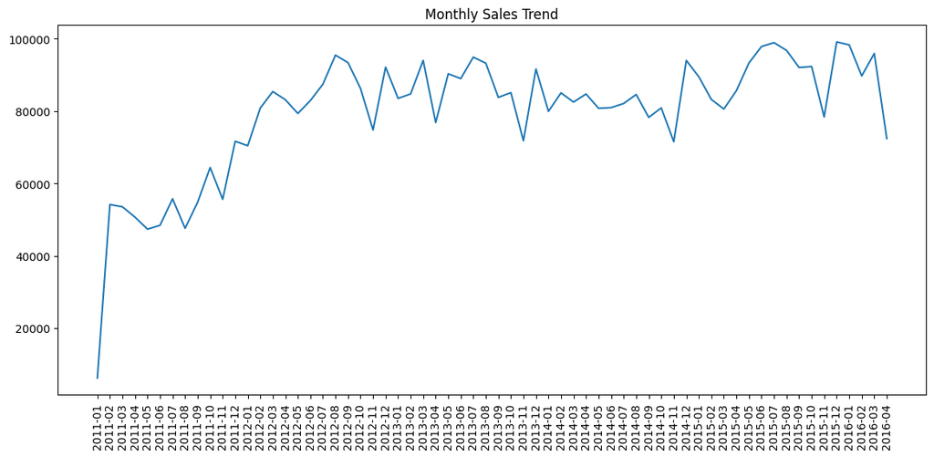

```python
# Monthly Trend Plot
plt.figure(figsize=(14,6))

plt.plot(
    monthly_sales["year_month"].astype(str),
    monthly_sales["sales"]
)

plt.title("Monthly Sales Trend")
plt.xticks(rotation=90)

plt.show()
```

```python
# Highest Sales Month
monthly_sales.loc[
    monthly_sales["sales"].idxmax()
]
```

```
year_month    2015-12
sales           99072
Name: 59, dtype: object
```

```python
# Lowest Sales Month
monthly_sales.loc[
    monthly_sales["sales"].idxmin()
]
```

```
year_month    2011-01
sales            6216
Name: 0, dtype: object
```

```python
# Yearly Aggregation
daily_sales["year"] = (
    daily_sales["date"]
    .dt.year
)

yearly_sales = (
    daily_sales
    .groupby("year")["sales"]
    .sum()
    .reset_index()
)

yearly_sales
```

|  | year | sales |
| --- | --- | --- |
| 0 | 2011 | 610070 |
| 1 | 2012 | 1011192 |
| 2 | 2013 | 1038468 |
| 3 | 2014 | 984877 |
| 4 | 2015 | 1087217 |
| 5 | 2016 | 356217 |

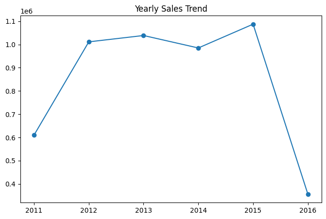

```python
# Yearly Trend Plot
plt.figure(figsize=(8,5))

plt.plot(
    yearly_sales["year"],
    yearly_sales["sales"],
    marker="o"
)

plt.title("Yearly Sales Trend")

plt.show()
```

```python
# Weekend Analysis
daily_sales["day_name"] = (
    daily_sales["date"]
    .dt.day_name()
)

daily_sales.head()
```

|  | date | sales | year_month | year | day_name |
| --- | --- | --- | --- | --- | --- |
| 0 | 2011-01-29 | 2343 | 2011-01 | 2011 | Saturday |
| 1 | 2011-01-30 | 2216 | 2011-01 | 2011 | Sunday |
| 2 | 2011-01-31 | 1657 | 2011-01 | 2011 | Monday |
| 3 | 2011-02-01 | 1508 | 2011-02 | 2011 | Tuesday |
| 4 | 2011-02-02 | 1209 | 2011-02 | 2011 | Wednesday |

```python
# Average Sales By Day
daily_sales.groupby(
    "day_name"
)["sales"].mean().sort_values(
    ascending=False
)
```

```
day_name
Saturday     3228.270073
Sunday       2886.167883
Friday       2815.772894
Thursday     2492.842491
Wednesday    2434.512821
Tuesday      2383.802198
Monday       2373.747253
Name: sales, dtype: float64
```

```python
# Create Prophet-ready dataset
prophet_df = daily_sales[
    ["date", "sales"]
].copy()

prophet_df.columns = [
    "ds",
    "y"
]

prophet_df.head()
```

|  | ds | y |
| --- | --- | --- |
| 0 | 2011-01-29 | 2343 |
| 1 | 2011-01-30 | 2216 |
| 2 | 2011-01-31 | 1657 |
| 3 | 2011-02-01 | 1508 |
| 4 | 2011-02-02 | 1209 |

```python
prophet_df.shape
```

```
(1913, 2)
```

```python
prophet_df.isnull().sum()
```

```
ds    0
y     0
dtype: int64
```

```python
prophet_df.describe()
```

|  | ds | y |
| --- | --- | --- |
| count | 1913 | 1913.000000 |
| mean | 2013-09-11 00:00:00 | 2659.718244 |
| min | 2011-01-29 00:00:00 | 0.000000 |
| 25% | 2012-05-21 00:00:00 | 2282.000000 |
| 50% | 2013-09-11 00:00:00 | 2654.000000 |
| 75% | 2015-01-02 00:00:00 | 3068.000000 |
| max | 2016-04-24 00:00:00 | 5493.000000 |
| std | NaN | 648.039653 |

```python
# Final Save prophet ready dataset
prophet_df.to_csv(
    r"C:\Users\LENOVO\Desktop\Zalima Development Project 2\Retail Demand Forecasting & Inventory optimization\data\processed\foods_1_prophet_ready.csv",
    index=False
)

print("Prophet Dataset Saved Successfully")
```

```
Prophet Dataset Saved Successfully
```

```python
# Save Cross Check
check_df = pd.read_csv(
    r"C:\Users\LENOVO\Desktop\Zalima Development Project 2\Retail Demand Forecasting & Inventory optimization\data\processed\foods_1_prophet_ready.csv"
)

check_df.shape
```

```
(1913, 2)
```

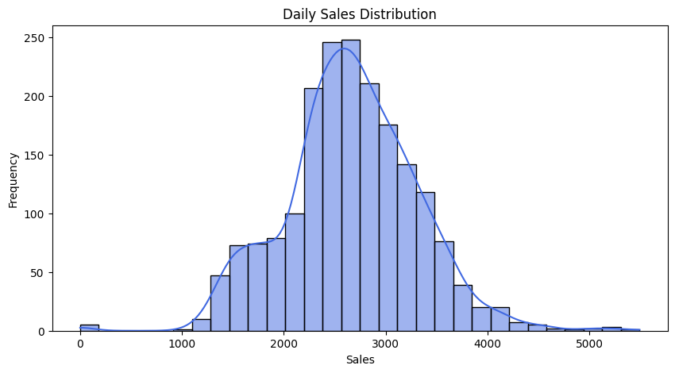

```python
# Additional Exploratory Data Analysis (EDA)
# Distribution & Outlier Analysis

# Sales Distribution Histogram
plt.figure(figsize=(10,5))

sns.histplot(
    daily_sales["sales"],
    bins=30,
    kde=True,
    color="royalblue"
)

plt.title("Daily Sales Distribution")
plt.xlabel("Sales")
plt.ylabel("Frequency")

plt.show()
```

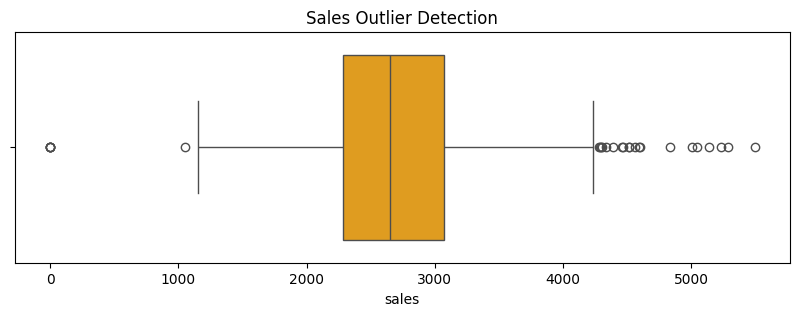

```python
# Sales Boxplot
plt.figure(figsize=(10,3))

sns.boxplot(
    x=daily_sales["sales"],
    color="orange"
)

plt.title("Sales Outlier Detection")

plt.show()
```

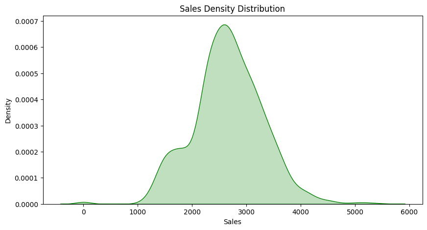

```python
# KDE Density Plot
plt.figure(figsize=(10,5))

sns.kdeplot(
    daily_sales["sales"],
    fill=True,
    color="green"
)

plt.title("Sales Density Distribution")

plt.xlabel("Sales")

plt.show()
```

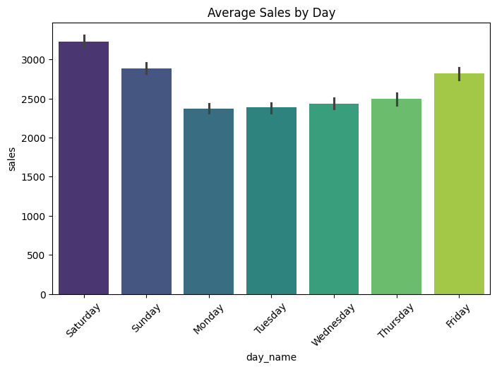

```python
# Weekend vs Weekday Sales
plt.figure(figsize=(8,5))

sns.barplot(
    data=daily_sales,
    x="day_name",
    y="sales",
    hue="day_name",
    palette="viridis",
    legend=False
)

plt.title("Average Sales by Day")
plt.xticks(rotation=45)

plt.show()
```

```python
daily_sales["sales"].describe()
```

```
count    1913.000000
mean     2659.718244
std       648.039653
min         0.000000
25%      2282.000000
50%      2654.000000
75%      3068.000000
max      5493.000000
Name: sales, dtype: float64
```

# Time Series EDA & Prophet Dataset Preparation Summary

## Objective

The objective of this notebook was to analyze the sales behavior of the FOODS_1 department before building a forecasting model and to prepare a clean dataset for Prophet forecasting.

## Work Completed

### 1. Daily Sales Aggregation

- Aggregated item-level sales into daily sales.
- Created a time series dataset with 1,913 daily observations.
- Verified there were no missing dates or missing sales values.

### 3. Seasonality Analysis

- Monthly sales patterns showed recurring fluctuations.
- Highest sales month: December 2015.
- Seasonal demand patterns were visible in the data.

### 4. Day-wise Sales Analysis

- Compared average sales across weekdays.
- Saturday recorded the highest average demand.
- Monday recorded the lowest average demand.
- Confirmed a strong weekend effect.

### 5. Distribution Analysis

- Examined sales distribution using histogram and density plots.
- Most daily sales values were concentrated between 2,000 and 3,500 units.
- Sales distribution was slightly right-skewed.

### 6. Outlier Analysis

- Used boxplots to identify unusual sales spikes.
- Found a few high-demand periods, which are normal for retail sales.

### 7. Prophet Dataset Preparation

- Converted dataset into Prophet format:
  - ds = Date
  - y = Sales
- Created a clean forecasting dataset with no missing values.
- Saved the final dataset for model training.

## Output File

foods_1_prophet_ready.csv